# Machine Learning Assignment Writeup

Agape

Oktober 2016

## Synopsis

### Background

Using devices such as Jawbone Up, Nike FuelBand, and Fitbit it is now possible to collect a large amount of data about personal activity relatively inexpensively. These type of devices are part of the quantified self movement - a group of enthusiasts who take measurements about themselves regularly to improve their health, to find patterns in their behavior, or because they are tech geeks. One thing that people regularly do is quantify how much of a particular activity they do, but they rarely quantify how well they do it. In this project, your goal will be to use data from accelerometers on the belt, forearm, arm, and dumbell of 6 participants. They were asked to perform barbell lifts correctly and incorrectly in 5 different ways. More information is available from the website here: http://groupware.les.inf.puc-rio.br/har (see the section on the Weight Lifting Exercise Dataset).

This Machine Learning Write UP predicts the achievement of participants exercise, which are represented by categorical variables,classe A, B, C, D, E. Two model choices for training the predictor are applied. The Random Forest confirms high Accuracy which is than used for answering 20 test cases.

### DATA: Processing / Loading / Importing / Cleaning / Splitting

#### Prepare Workspace

```r
testing <- read.csv("pml-testing.csv", na.strings = c("NA", ""))
training <- read.csv("pml-training.csv", na.strings = c("NA", ""))
```

Summary of the dataset: Dataset training has 1’9622 observations and 160 variables, where the testing dataset has 20 observations with same number of variables as training-dataset.The prediction of outcome will be applied on the training-dataset. ###CLEANING Columns to be deleted within the training set which contain missing values.

```r
testing <-    testing[, colSums(is.na(testing)) == 0]
training <-   training[, colSums(is.na(training)) == 0]
```

```r
trainData1 <- training[, -c(1:7)]
testData1 <- testing[, -c(1:7)]
```

### Spliting

```r
library(caret)
set.seed(8000)
inTrain <- createDataPartition(trainData1$classe, p = 0.7, list = FALSE)
train <- trainData1[inTrain, ]
valid <- trainData1[-inTrain, ]
```

### Prediction Algorithms (classification trees and random forests) for prediciton of the outcome.

### Classification trees

```r
control <- trainControl(method = "cv", number = 5)
fit_rpart <- train(classe ~ ., data = train, method = "rpart", trControl = control)
print(fit_rpart, digits = 4)
```

```
## CART
##
## 13737 samples
##    52 predictor
##     5 classes: 'A', 'B', 'C', 'D', 'E'
##
## No pre-processing
## Resampling: Cross-Validated (5 fold)
## Summary of sample sizes: 10989, 10989, 10991, 10989, 10990
## Resampling results across tuning parameters:
##
##   cp       Accuracy  Kappa
##   0.03428  0.5097    0.3601
##   0.06076  0.4155    0.2077
##   0.11647  0.3328    0.0738
##
## Accuracy was used to select the optimal model using  the largest value.
## The final value used for the model was cp = 0.03428.
```

[output not shown]

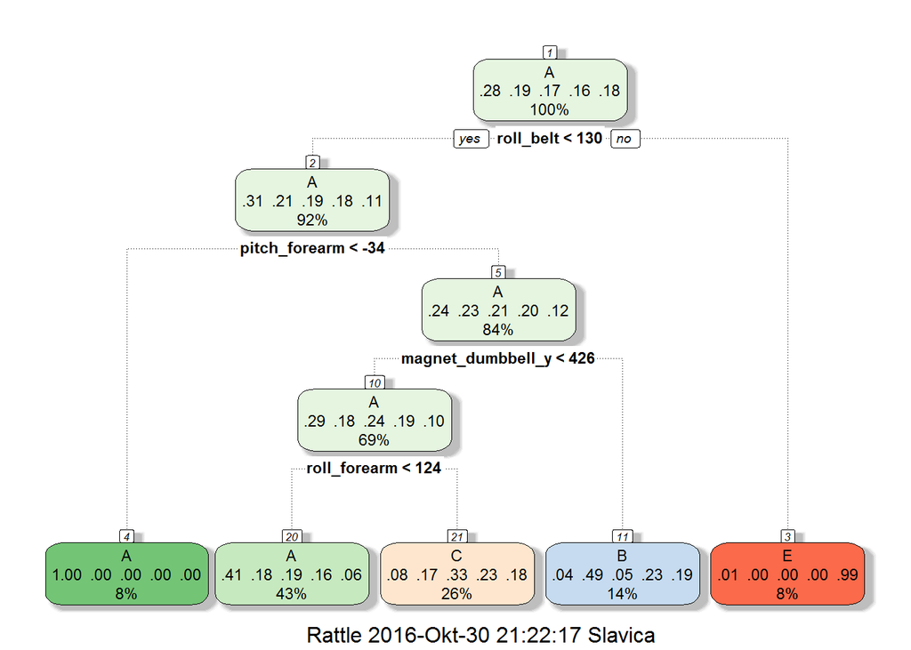

```r
fancyRpartPlot(fit_rpart$finalModel)
```

###Outcome prediction applied on validation set

```r
prediction_rpart <- predict(fit_rpart, valid)
#Prediction Results
(conf_rpart <- confusionMatrix(valid$classe, prediction_rpart))
```

```
## Confusion Matrix and Statistics
##
##           Reference
## Prediction    A    B    C    D    E
##          A 1509   41  118    0    6
##          B  454  383  302    0    0
##          C  460   32  534    0    0
##          D  448  163  353    0    0
##          E  155  147  302    0  478
##
## Overall Statistics
##
##                Accuracy : 0.4935
##                  95% CI : (0.4806, 0.5063)
##     No Information Rate : 0.5142
##     P-Value [Acc > NIR] : 0.9993
##
##                   Kappa : 0.3385
##  Mcnemar's Test P-Value : NA
##
## Statistics by Class:
##
##                      Class: A Class: B Class: C Class: D Class: E
## Sensitivity            0.4987  0.50000  0.33188       NA  0.98760
## Specificity            0.9423  0.85231  0.88494   0.8362  0.88817
## Pos Pred Value         0.9014  0.33626  0.52047       NA  0.44177
## Neg Pred Value         0.6398  0.91930  0.77876       NA  0.99875
## Prevalence             0.5142  0.13016  0.27341   0.0000  0.08224
## Detection Rate         0.2564  0.06508  0.09074   0.0000  0.08122
## Detection Prevalence   0.2845  0.19354  0.17434   0.1638  0.18386
## Balanced Accuracy      0.7205  0.67616  0.60841       NA  0.93789
```

```r
(accuracy_rpart <- conf_rpart$overall[1])
```

```
##  Accuracy
## 0.4934579
```

The accuracy rate is 0.49. Use of classification tree is suboptimal

### Apply Random forests for optimization

```r
#library(randomForest)
fit_rf <- train(classe ~ ., data = train, method = "rf", trControl = control)
print(fit_rf, digits = 4)
```

```
## Random Forest
##
## 13737 samples
##    52 predictor
##     5 classes: 'A', 'B', 'C', 'D', 'E'
##
## No pre-processing
## Resampling: Cross-Validated (5 fold)
## Summary of sample sizes: 10990, 10988, 10990, 10990, 10990
## Resampling results across tuning parameters:
##
##   mtry  Accuracy  Kappa
##    2    0.9901    0.9875
##   27    0.9906    0.9881
##   52    0.9809    0.9758
##
## Accuracy was used to select the optimal model using  the largest value.
## The final value used for the model was mtry = 27.
```

### Prediction of outcomes using validation set

```r
predict_rf <- predict(fit_rf, valid)
# prediction result
(conf_rf <- confusionMatrix(valid$classe, predict_rf))
```

```
## Confusion Matrix and Statistics
##
##           Reference
## Prediction    A    B    C    D    E
##          A 1672    2    0    0    0
##          B    1 1135    3    0    0
##          C    0    3 1019    4    0
##          D    0    0   13  950    1
##          E    0    0    1    6 1075
##
## Overall Statistics
##
##                Accuracy : 0.9942
##                  95% CI : (0.9919, 0.996)
##     No Information Rate : 0.2843
##     P-Value [Acc > NIR] : < 2.2e-16
##
##                   Kappa : 0.9927
##  Mcnemar's Test P-Value : NA
##
## Statistics by Class:
##
##                      Class: A Class: B Class: C Class: D Class: E
## Sensitivity            0.9994   0.9956   0.9836   0.9896   0.9991
## Specificity            0.9995   0.9992   0.9986   0.9972   0.9985
## Pos Pred Value         0.9988   0.9965   0.9932   0.9855   0.9935
## Neg Pred Value         0.9998   0.9989   0.9965   0.9980   0.9998
## Prevalence             0.2843   0.1937   0.1760   0.1631   0.1828
## Detection Rate         0.2841   0.1929   0.1732   0.1614   0.1827
## Detection Prevalence   0.2845   0.1935   0.1743   0.1638   0.1839
## Balanced Accuracy      0.9995   0.9974   0.9911   0.9934   0.9988
```

```r
(accuracy_rf <- conf_rf$overall[1])
```

```
##  Accuracy
## 0.9942226
```

Very high Accuracy achieved with Random Forest, 99.42%

### Use random forests to predict the outcome variable classe for the testing set which are in fact the answers for the quiz.

```r
(predict(fit_rf, testData1))
```

```
##  [1] B A B A A E D B A A B C B A E E A B B B
## Levels: A B C D E
```